# Assignment Week 2

Carla Ebner

2025-03-03

1.1.1. We load the AnnotationHub library

```r
suppressPackageStartupMessages({
  library(AnnotationHub) # to fetch genomes, annotations, etc.
  library(ensembldb)     # to manipulate ensembl gene annotations
  library(GenomicRanges) # data structure for genomic ranges
  library(epiwraps)      # visualization
})
```

1.1.2. We generate an AnnotationHub object called ah

```r
ah <- AnnotationHub()
```

1.1.3. We search for the mouse EnsDb object and show the results that we found

```r
query_results1 <- query(ah, c("Mus musculus", "EnsDb", "GRCm38"))
print(query_results1)
```

```
## AnnotationHub with 16 records
## # snapshotDate(): 2024-10-28
## # $dataprovider: Ensembl
## # $species: Mus musculus
## # $rdataclass: EnsDb
## # additional mcols(): taxonomyid, genome, description,
## #   coordinate_1_based, maintainer, rdatadateadded, preparerclass, tags,
## #   rdatapath, sourceurl, sourcetype
## # retrieve records with, e.g., 'object[["AH53222"]]'
##
##             title
##   AH53222 | Ensembl 87 EnsDb for Mus Musculus
##   AH53726 | Ensembl 88 EnsDb for Mus Musculus
##   AH56691 | Ensembl 89 EnsDb for Mus Musculus
##   AH57770 | Ensembl 90 EnsDb for Mus Musculus
##   AH60788 | Ensembl 91 EnsDb for Mus Musculus
##   ...       ...
##   AH75036 | Ensembl 98 EnsDb for Mus musculus
##   AH78811 | Ensembl 99 EnsDb for Mus musculus
##   AH79718 | Ensembl 100 EnsDb for Mus musculus
##   AH83247 | Ensembl 101 EnsDb for Mus musculus
##   AH89211 | Ensembl 102 EnsDb for Mus musculus
```

1.1.4. Now we can see the ID of the object version 102, which is “AH89211”.We call this object “ensdb102” and show the content of it

```r
ensdb102 <- ah[["AH89211"]]
```

```
## loading from cache
```

```r
ensdb102
```

```
## EnsDb for Ensembl:
## |Backend: SQLite
## |Db type: EnsDb
## |Type of Gene ID: Ensembl Gene ID
## |Supporting package: ensembldb
## |Db created by: ensembldb package from Bioconductor
## |script_version: 0.3.6
## |Creation time: Sun Dec 20 12:15:16 2020
## |ensembl_version: 102
## |ensembl_host: localhost
## |Organism: Mus musculus
## |taxonomy_id: 10090
## |genome_build: GRCm38
## |DBSCHEMAVERSION: 2.1
## | No. of genes: 56305.
## | No. of transcripts: 144778.
## |Protein data available.
```

1.2.1. Now we search the mouse genome sequence (dna_sm) specifically in TwoBit/2bit format also for GRCm38

```r
query_results2 <- query(ah, c("Mus musculus", "dna_sm", "GRCm38", "2bit"))
print(query_results2)
```

```
## AnnotationHub with 19 records
## # snapshotDate(): 2024-10-28
## # $dataprovider: Ensembl
## # $species: Mus musculus, mus musculus
## # $rdataclass: TwoBitFile
## # additional mcols(): taxonomyid, genome, description,
## #   coordinate_1_based, maintainer, rdatadateadded, preparerclass, tags,
## #   rdatapath, sourceurl, sourcetype
## # retrieve records with, e.g., 'object[["AH49775"]]'
##
##             title
##   AH49775 | Mus_musculus.GRCm38.dna_sm.primary_assembly.2bit
##   AH50120 | Mus_musculus.GRCm38.dna_sm.primary_assembly.2bit
##   AH50611 | Mus_musculus.GRCm38.dna_sm.primary_assembly.2bit
##   AH51299 | Mus_musculus.GRCm38.dna_sm.primary_assembly.2bit
##   AH51645 | Mus_musculus.GRCm38.dna_sm.primary_assembly.2bit
##   ...       ...
##   AH70177 | Mus_musculus.GRCm38.dna_sm.primary_assembly.2bit
##   AH77927 | Mus_musculus.GRCm38.dna_sm.primary_assembly.2bit
##   AH82549 | Mus_musculus.GRCm38.dna_sm.primary_assembly.2bit
##   AH84787 | Mus_musculus.GRCm38.dna_sm.primary_assembly.2bit
##   AH88477 | Mus_musculus.GRCm38.dna_sm.primary_assembly.2bit
```

1.2.2. We download the newest version of it which is “AH88477”

```r
dna_2bit <- ah[["AH88477"]]
```

```
## loading from cache
```

```
## require("rtracklayer")
```

```r
dna_2bit
```

```
## TwoBitFile object
## resource: C:\Users\carla\AppData\Local/R/cache/R/AnnotationHub/472c2b256bd8_95223
```

1.3.1. Now we search the drosophila melanogaster genome sequence ( dna_sm ) in TwoBit/2bit format for BDGP6, which shows 24 results

```r
query_results3 <- query(ah, c("Drosophila melanogaster", "dna_sm", "BDGP6", "2bit"))
print(query_results3)
```

```
## AnnotationHub with 24 records
## # snapshotDate(): 2024-10-28
## # $dataprovider: Ensembl
## # $species: Drosophila melanogaster, drosophila melanogaster
## # $rdataclass: TwoBitFile
## # additional mcols(): taxonomyid, genome, description,
## #   coordinate_1_based, maintainer, rdatadateadded, preparerclass, tags,
## #   rdatapath, sourceurl, sourcetype
## # retrieve records with, e.g., 'object[["AH49674"]]'
##
##              title
##   AH49674  | Drosophila_melanogaster.BDGP6.dna_sm.toplevel.2bit
##   AH50019  | Drosophila_melanogaster.BDGP6.dna_sm.toplevel.2bit
##   AH50510  | Drosophila_melanogaster.BDGP6.dna_sm.toplevel.2bit
##   AH51198  | Drosophila_melanogaster.BDGP6.dna_sm.toplevel.2bit
##   AH51544  | Drosophila_melanogaster.BDGP6.dna_sm.toplevel.2bit
##   ...        ...
##   AH90691  | Drosophila_melanogaster.BDGP6.32.dna_sm.toplevel.2bit
##   AH92960  | Drosophila_melanogaster.BDGP6.32.dna_sm.toplevel.2bit
##   AH99424  | Drosophila_melanogaster.BDGP6.32.dna_sm.toplevel.2bit
##   AH103729 | Drosophila_melanogaster.BDGP6.32.dna_sm.toplevel.2bit
##   AH106160 | Drosophila_melanogaster.BDGP6.32.dna_sm.toplevel.2bit
```

1.3.2. We download the newest version, which is “AH106160”

```r
drosophila <- ah[["AH106160"]]
```

```
## loading from cache
```

```r
drosophila
```

```
## TwoBitFile object
## resource: C:\Users\carla\AppData\Local/R/cache/R/AnnotationHub/472c383f7989_112906
```

2.1.1. As a first step we save all gene data from the EnsDb object from before in a new variable called “gene”. We do this, so that we can filter this data specifically later on

```r
genes <- genes(ensdb102)
genes
```

```
## GRanges object with 56305 ranges and 9 metadata columns:
##                      seqnames            ranges strand |            gene_id
##                         <Rle>         <IRanges>  <Rle> |        <character>
##   ENSMUSG00000102693        1   3073253-3074322      + | ENSMUSG00000102693
##   ENSMUSG00000064842        1   3102016-3102125      + | ENSMUSG00000064842
##   ENSMUSG00000051951        1   3205901-3671498      - | ENSMUSG00000051951
##   ENSMUSG00000102851        1   3252757-3253236      + | ENSMUSG00000102851
##   ENSMUSG00000103377        1   3365731-3368549      - | ENSMUSG00000103377
##                  ...      ...               ...    ... .                ...
##   ENSMUSG00000095366        Y 90752427-90755467      - | ENSMUSG00000095366
##   ENSMUSG00000095134        Y 90753057-90763485      + | ENSMUSG00000095134
##   ENSMUSG00000096768        Y 90784738-90816465      + | ENSMUSG00000096768
##   ENSMUSG00000099871        Y 90837413-90844040      + | ENSMUSG00000099871
##   ENSMUSG00000096850        Y 90838869-90839177      - | ENSMUSG00000096850
##                          gene_name           gene_biotype seq_coord_system
##                        <character>            <character>      <character>
##   ENSMUSG00000102693 4933401J01Rik                    TEC       chromosome
##   ENSMUSG00000064842       Gm26206                  snRNA       chromosome
##   ENSMUSG00000051951          Xkr4         protein_coding       chromosome
##   ENSMUSG00000102851       Gm18956   processed_pseudogene       chromosome
##   ENSMUSG00000103377       Gm37180                    TEC       chromosome
##                  ...           ...                    ...              ...
##   ENSMUSG00000095366       Gm21860                lincRNA       chromosome
##   ENSMUSG00000095134      Mid1-ps1 unprocessed_pseudogene       chromosome
##   ENSMUSG00000096768       Gm47283                lincRNA       chromosome
##   ENSMUSG00000099871       Gm21742 unprocessed_pseudogene       chromosome
##   ENSMUSG00000096850       Gm21748         protein_coding       chromosome
##                                 description      gene_id_version
##                                 <character>          <character>
##   ENSMUSG00000102693 RIKEN cDNA 4933401J0.. ENSMUSG00000102693.1
##   ENSMUSG00000064842 predicted gene, 2620.. ENSMUSG00000064842.1
##   ENSMUSG00000051951 X-linked Kx blood gr.. ENSMUSG00000051951.5
##   ENSMUSG00000102851 predicted gene, 1895.. ENSMUSG00000102851.1
##   ENSMUSG00000103377 predicted gene, 3718.. ENSMUSG00000103377.1
##                  ...                    ...                  ...
##   ENSMUSG00000095366 predicted gene, 2186.. ENSMUSG00000095366.2
##   ENSMUSG00000095134 midline 1, pseudogen.. ENSMUSG00000095134.2
##   ENSMUSG00000096768 predicted gene, 4728.. ENSMUSG00000096768.8
##   ENSMUSG00000099871 predicted gene, 2174.. ENSMUSG00000099871.1
##   ENSMUSG00000096850 predicted gene, 2174.. ENSMUSG00000096850.1
##                      canonical_transcript        symbol entrezid
##                               <character>   <character>   <list>
##   ENSMUSG00000102693   ENSMUST00000193812 4933401J01Rik     <NA>
##   ENSMUSG00000064842   ENSMUST00000082908       Gm26206     <NA>
##   ENSMUSG00000051951   ENSMUST00000070533          Xkr4   497097
##   ENSMUSG00000102851   ENSMUST00000192857       Gm18956     <NA>
##   ENSMUSG00000103377   ENSMUST00000195335       Gm37180     <NA>
##                  ...                  ...           ...      ...
##   ENSMUSG00000095366   ENSMUST00000238676       Gm21860     <NA>
##   ENSMUSG00000095134   ENSMUST00000167967      Mid1-ps1     <NA>
##   ENSMUSG00000096768   ENSMUST00000179483       Gm47283     <NA>
##   ENSMUSG00000099871   ENSMUST00000189352       Gm21742     <NA>
##   ENSMUSG00000096850   ENSMUST00000179623       Gm21748     <NA>
##   -------
##   seqinfo: 118 sequences (1 circular) from GRCm38 genome
```

2.1.2. Now we filter the content of the “gene” variable for only protein-coding genes. We save this new filtered date in a new variable called “pcgenes”

```r
pcgenes <- genes[which(genes$gene_biotype=="protein_coding")]
pcgenes
```

```
## GRanges object with 22287 ranges and 9 metadata columns:
##                      seqnames            ranges strand |            gene_id
##                         <Rle>         <IRanges>  <Rle> |        <character>
##   ENSMUSG00000051951        1   3205901-3671498      - | ENSMUSG00000051951
##   ENSMUSG00000025900        1   3999557-4409241      - | ENSMUSG00000025900
##   ENSMUSG00000025902        1   4490931-4497354      - | ENSMUSG00000025902
##   ENSMUSG00000033845        1   4773206-4785739      - | ENSMUSG00000033845
##   ENSMUSG00000025903        1   4807788-4848410      + | ENSMUSG00000025903
##                  ...      ...               ...    ... .                ...
##   ENSMUSG00000101915        Y 88053315-88079494      + | ENSMUSG00000101915
##   ENSMUSG00000102045        Y 89052806-89079015      + | ENSMUSG00000102045
##   ENSMUSG00000100608        Y 89713424-89745532      - | ENSMUSG00000100608
##   ENSMUSG00000096178        Y 90401248-90433263      + | ENSMUSG00000096178
##   ENSMUSG00000096850        Y 90838869-90839177      - | ENSMUSG00000096850
##                        gene_name   gene_biotype seq_coord_system
##                      <character>    <character>      <character>
##   ENSMUSG00000051951        Xkr4 protein_coding       chromosome
##   ENSMUSG00000025900         Rp1 protein_coding       chromosome
##   ENSMUSG00000025902       Sox17 protein_coding       chromosome
##   ENSMUSG00000033845      Mrpl15 protein_coding       chromosome
##   ENSMUSG00000025903      Lypla1 protein_coding       chromosome
##                  ...         ...            ...              ...
##   ENSMUSG00000101915     Gm28102 protein_coding       chromosome
##   ENSMUSG00000102045     Gm21294 protein_coding       chromosome
##   ENSMUSG00000100608     Gm21996 protein_coding       chromosome
##   ENSMUSG00000096178     Gm20837 protein_coding       chromosome
##   ENSMUSG00000096850     Gm21748 protein_coding       chromosome
##                                 description       gene_id_version
##                                 <character>           <character>
##   ENSMUSG00000051951 X-linked Kx blood gr..  ENSMUSG00000051951.5
##   ENSMUSG00000025900 retinitis pigmentosa.. ENSMUSG00000025900.13
##   ENSMUSG00000025902 SRY (sex determining.. ENSMUSG00000025902.13
##   ENSMUSG00000033845 mitochondrial riboso.. ENSMUSG00000033845.13
##   ENSMUSG00000025903 lysophospholipase 1 .. ENSMUSG00000025903.14
##                  ...                    ...                   ...
##   ENSMUSG00000101915 predicted gene 28102..  ENSMUSG00000101915.1
##   ENSMUSG00000102045 predicted gene, 2129..  ENSMUSG00000102045.1
##   ENSMUSG00000100608 predicted gene 21996..  ENSMUSG00000100608.1
##   ENSMUSG00000096178 predicted gene, 2083..  ENSMUSG00000096178.7
##   ENSMUSG00000096850 predicted gene, 2174..  ENSMUSG00000096850.1
##                      canonical_transcript      symbol entrezid
##                               <character> <character>   <list>
##   ENSMUSG00000051951   ENSMUST00000070533        Xkr4   497097
##   ENSMUSG00000025900   ENSMUST00000027032         Rp1    19888
##   ENSMUSG00000025902   ENSMUST00000027035       Sox17    20671
##   ENSMUSG00000033845   ENSMUST00000156816      Mrpl15    27395
##   ENSMUSG00000025903   ENSMUST00000027036      Lypla1    18777
##                  ...                  ...         ...      ...
##   ENSMUSG00000101915   ENSMUST00000187146     Gm28102     <NA>
##   ENSMUSG00000102045   ENSMUST00000186443     Gm21294     <NA>
##   ENSMUSG00000100608   ENSMUST00000188269     Gm21996     <NA>
##   ENSMUSG00000096178   ENSMUST00000190558     Gm20837     <NA>
##   ENSMUSG00000096850   ENSMUST00000179623     Gm21748     <NA>
##   -------
##   seqinfo: 118 sequences (1 circular) from GRCm38 genome
```

2.1.3. We now want to know how many different gene IDs and gene symbols we have in this newly formed variable “pcgenes”. With the function length(unique()) we make sure that we only count the different gene IDs/gene symbols

```r
length(unique(pcgenes$gene_name))
```

```
## [1] 21964
```

```r
length(unique(pcgenes$gene_id))
```

```
## [1] 22287
```

2.2.1. First we search for the exons of the mouse and filter them specifically for protein-coding ones, while splitting them by transcript

```r
pc_mouseExons <- exonsBy(ensdb102, by = "tx", filter = GeneBiotypeFilter("protein_coding"))
```

2.2.2. We sum the width of the exons of each transcript, we do this with the function “sapply()”, so that we don’t just calculate the whole width of all exons, but the width in each transcript. Using the “head()” function, we control our calcuation. Here we can see that for example for the transcript ENSMUST00000000001 the length of all exons is 3262 bp

```r
transcript_lengths <- sapply(pc_mouseExons, function(x) sum(width(x)))
head(transcript_lengths)
```

```
## ENSMUST00000000001 ENSMUST00000000003 ENSMUST00000000010 ENSMUST00000000028
##               3262                902               2574               2143
## ENSMUST00000000033 ENSMUST00000000049
##               3708               1190
```

2.2.3. Now we need to visualize our list and we use ggplot for this

```r
library(ggplot2)
```

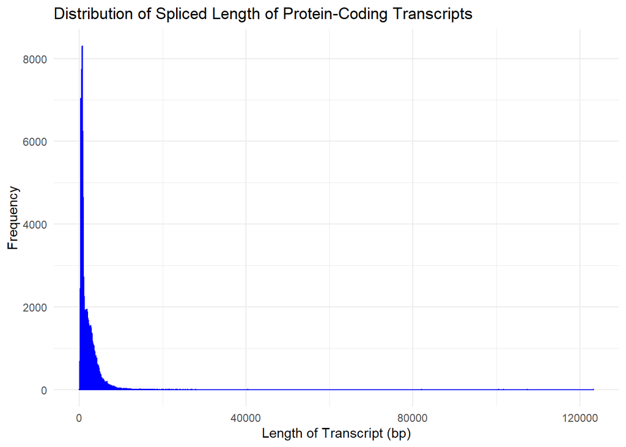

```r
ggplot(data.frame(length = transcript_lengths), aes(x = length)) +
  geom_histogram(binwidth = 100, fill = "blue", color = "blue") +
  labs(title = "Distribution of Spliced Length of Protein-Coding Transcripts",
       x = "Length of Transcript (bp)",
       y = "Frequency") +
  theme_minimal()
```